```python
%matplotlib inline
import numpy as np
import pandas as pd
from sklearn.model_selection import train_test_split
from sklearn.neighbors import KNeighborsClassifier
from sklearn.metrics import accuracy_score
from sklearn import svm
from scipy.stats import zscore
from sklearn.linear_model import LogisticRegression
import seaborn as sns
import matplotlib.pyplot as plt
```

# Part A

## 1.A

```python
normal_csv = pd.read_csv("Part1+-+Normal.csv")
type_h_csv = pd.read_csv("Part1+-+Type_H.csv")
type_s_csv = pd.read_csv("Part1+-+Type_S.csv")
```

## 1.B

```python
normal_shape = normal_csv.shape
print("normal dataframe")
print("Shape          : " , normal_shape)
print("no. of columns : ", normal_csv.shape[1])
```

```
normal dataframe
Shape          :  (100, 7)
no. of columns :  7
```

```python
type_h_shape = type_h_csv.shape
print("type-h dataframe")
print("shape :", type_h_shape)
print("columns : " , type_h_shape[1])
```

```
type-h dataframe
shape : (60, 7)
columns :  7
```

```python
type_s_shape = type_s_csv.shape
print("type-s dataframe")
print("shape : ", type_s_shape)
print("Columns : " , type_s_shape[1])
```

```
type-s dataframe
shape :  (150, 7)
Columns :  7
```

## 1.C

```python
normal_cols = normal_csv.columns
type_h_cols = type_h_csv.columns
type_s_cols = type_s_csv.columns

if set(normal_csv.columns) == set(type_h_csv.columns):
    print('normal_csv and type_h have the same columns')
else:
    print('type_h_csv and normal_csv have different columns')

if set(normal_csv.columns) == set(type_s_csv.columns):
    print('normal_csv and type_s have the same columns')
else:
    print('type_s_csv and normal_csv have different columns')
```

```
normal_csv and type_h have the same columns
normal_csv and type_s have the same columns
```

This shows that all 3 dataframes have same column names

## 1.D

```python
print("normal dataframe")
normal_csv.dtypes
```

```
normal dataframe
```

```
P_incidence    float64
P_tilt         float64
L_angle        float64
S_slope        float64
P_radius       float64
S_Degree       float64
Class           object
dtype: object
```

```python
print("type-h dataframe")
type_h_csv.dtypes
```

```
type-h dataframe
```

```
P_incidence    float64
P_tilt         float64
L_angle        float64
S_slope        float64
P_radius       float64
S_Degree       float64
Class           object
dtype: object
```

```python
print("type-s dataframe")
type_s_csv.dtypes
```

```
type-s dataframe
```

```
P_incidence    float64
P_tilt         float64
L_angle        float64
S_slope        float64
P_radius       float64
S_Degree       float64
Class           object
dtype: object
```

## 1.E

```python
print(normal_csv["Class"].unique())
print(type_h_csv["Class"].unique())
print(type_s_csv["Class"].unique())
```

```
['Normal' 'Nrmal']
['Type_H' 'type_h']
['Type_S' 'tp_s']
```

## 2.A

```python
normal_csv["Class"] = "normal"
type_h_csv["Class"] = "type_h"
type_s_csv["Class"] = "type_s"
```

```python
print(normal_csv["Class"].unique())
print(type_h_csv["Class"].unique())
print(type_s_csv["Class"].unique())
```

```
['normal']
['type_h']
['type_s']
```

## 2.B

```python
final_df = pd.concat([normal_csv, type_h_csv, type_s_csv])
display(final_df)
```

|  | P_incidence | P_tilt | L_angle | S_slope | P_radius | S_Degree | Class |
| --- | --- | --- | --- | --- | --- | --- | --- |
| 0 | 38.505273 | 16.964297 | 35.112814 | 21.540976 | 127.632875 | 7.986683 | normal |
| 1 | 54.920858 | 18.968430 | 51.601455 | 35.952428 | 125.846646 | 2.001642 | normal |
| 2 | 44.362490 | 8.945435 | 46.902096 | 35.417055 | 129.220682 | 4.994195 | normal |
| 3 | 48.318931 | 17.452121 | 48.000000 | 30.866809 | 128.980308 | -0.910941 | normal |
| 4 | 45.701789 | 10.659859 | 42.577846 | 35.041929 | 130.178314 | -3.388910 | normal |
| ... | ... | ... | ... | ... | ... | ... | ... |
| 145 | 80.111572 | 33.942432 | 85.101608 | 46.169139 | 125.593624 | 100.292107 | type_s |
| 146 | 95.480229 | 46.550053 | 59.000000 | 48.930176 | 96.683903 | 77.283072 | type_s |
| 147 | 74.094731 | 18.823727 | 76.032156 | 55.271004 | 128.405731 | 73.388216 | type_s |
| 148 | 87.679087 | 20.365613 | 93.822416 | 67.313473 | 120.944829 | 76.730629 | type_s |
| 149 | 48.259920 | 16.417462 | 36.329137 | 31.842457 | 94.882336 | 28.343799 | type_s |

310 rows × 7 columns

## 2.C

```python
final_df.sample(5)
```

|  | P_incidence | P_tilt | L_angle | S_slope | P_radius | S_Degree | Class |
| --- | --- | --- | --- | --- | --- | --- | --- |
| 42 | 70.399308 | 13.469986 | 61.200000 | 56.929322 | 102.337524 | 25.538429 | type_s |
| 7 | 75.649731 | 19.339799 | 64.148685 | 56.309932 | 95.903629 | 69.551303 | type_s |
| 120 | 37.903910 | 4.479099 | 24.710274 | 33.424811 | 157.848799 | 33.607027 | type_s |
| 17 | 31.276012 | 3.144669 | 32.562996 | 28.131342 | 129.011418 | 3.623020 | type_h |
| 44 | 77.409333 | 29.396545 | 63.232302 | 48.012788 | 118.450731 | 93.563737 | type_s |

## 2.D

```python
percent_missing = final_df.isnull().sum() * 100 / len(final_df)
missing_value_df = pd.DataFrame({'column_name': final_df.columns,
                                 'percent_missing': percent_missing})
print(missing_value_df)
```

```
             column_name  percent_missing
P_incidence  P_incidence              0.0
P_tilt            P_tilt              0.0
L_angle          L_angle              0.0
S_slope          S_slope              0.0
P_radius        P_radius              0.0
S_Degree        S_Degree              0.0
Class              Class              0.0
```

## 2.E

```python
final_df.describe().loc[['min', '25%', '50%', '75%', 'max']]
```

|  | P_incidence | P_tilt | L_angle | S_slope | P_radius | S_Degree |
| --- | --- | --- | --- | --- | --- | --- |
| min | 26.147921 | -6.554948 | 14.000000 | 13.366931 | 70.082575 | -11.058179 |
| 25% | 46.430294 | 10.667069 | 37.000000 | 33.347122 | 110.709196 | 1.603727 |
| 50% | 58.691038 | 16.357689 | 49.562398 | 42.404912 | 118.268178 | 11.767934 |
| 75% | 72.877696 | 22.120395 | 63.000000 | 52.695888 | 125.467674 | 41.287352 |
| max | 129.834041 | 49.431864 | 125.742385 | 121.429566 | 163.071041 | 418.543082 |

## 3.A

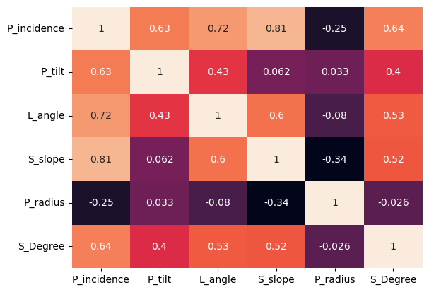

```python
sns.heatmap(data=final_df[final_df.columns].corr(), annot=True, cbar=False);
```

## 3.B

#### A. Features having stronger correlation with correlation value:

p_incidence and s_slope : 0.81  
p_incidence and l_angle : 0.72

#### B. Features having weaker correlation with correlation value :

p_radius and s_degree : -0.026  
p_radius and p_tilt : 0.033  
s_slope and p_tilt : 0.062  
p_radius and l_angle : -0.08

## 3.C

```python
final_df.columns
```

```
Index(['P_incidence', 'P_tilt', 'L_angle', 'S_slope', 'P_radius', 'S_Degree',
       'Class'],
      dtype='object')
```

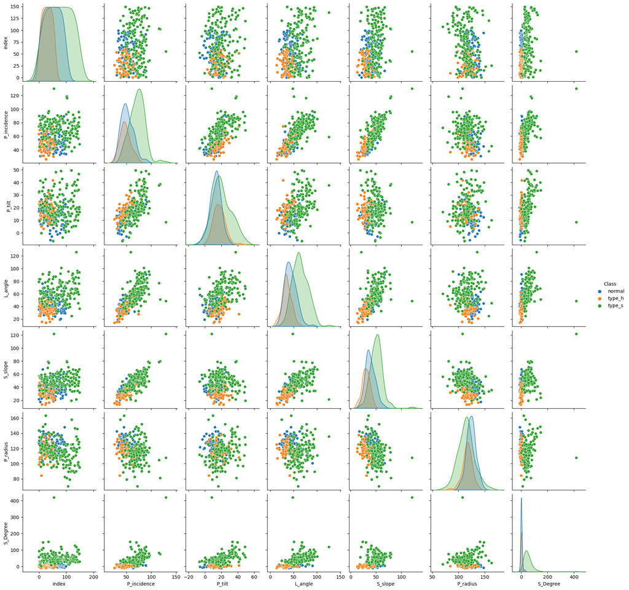

```python
final_df = final_df.reset_index()
sns.pairplot(final_df, hue="Class")
```

## 3.D

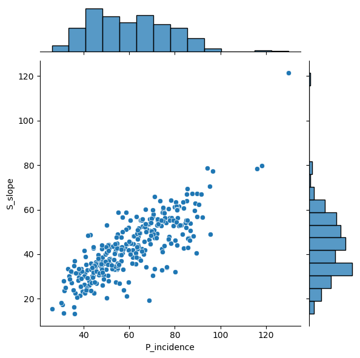

```python
sns.jointplot(data=final_df, x='P_incidence', y='S_slope');
```

this Shows that p_incidence and s_slope are directly proportional to each other for the most part

## 3.E

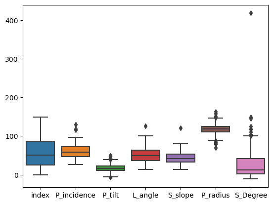

```python
sns.boxplot(data=final_df);
```

It shows that the data has a lot of outliers an will need some work to get that normalised for proper data processing

## 4.A

```python
x = final_df.drop(labels="Class" , axis=1)
y = final_df["Class"]
```

```python
XScaled = x.apply(zscore)
XScaled.describe()
```

|  | index | P_incidence | P_tilt | L_angle | S_slope | P_radius | S_Degree |
| --- | --- | --- | --- | --- | --- | --- | --- |
| count | 3.100000e+02 | 3.100000e+02 | 3.100000e+02 | 3.100000e+02 | 3.100000e+02 | 3.100000e+02 | 3.100000e+02 |
| mean | 2.865092e-17 | 1.042177e-16 | 2.096889e-16 | 1.980495e-16 | 2.829278e-17 | -5.071212e-16 | -1.277204e-16 |
| std | 1.001617e+00 | 1.001617e+00 | 1.001617e+00 | 1.001617e+00 | 1.001617e+00 | 1.001617e+00 | 1.001617e+00 |
| min | -1.468023e+00 | -1.996010e+00 | -2.411664e+00 | -2.047652e+00 | -2.207741e+00 | -3.597963e+00 | -9.961725e-01 |
| 25% | -8.258910e-01 | -8.173982e-01 | -6.881138e-01 | -8.060267e-01 | -7.168418e-01 | -5.423830e-01 | -6.585073e-01 |
| 50% | -1.710437e-01 | -1.049246e-01 | -1.186061e-01 | -1.278621e-01 | -4.095971e-02 | 2.613767e-02 | -3.874502e-01 |
| 75% | 7.126822e-01 | 7.194643e-01 | 4.581158e-01 | 5.975493e-01 | 7.269414e-01 | 5.676209e-01 | 3.997679e-01 |
| max | 2.321190e+00 | 4.029206e+00 | 3.191402e+00 | 3.984615e+00 | 5.855771e+00 | 3.395818e+00 | 1.046035e+01 |

## 4.B

```python
X_train, X_test, y_train, y_test = train_test_split(XScaled, y, test_size=0.20, random_state=1)
```

## 4.C

```python
NNH = KNeighborsClassifier(n_neighbors= 5 , weights = 'distance' )
```

```python
NNH.fit(X_train, y_train)
```

```
KNeighborsClassifier(weights='distance')
```

```python
predicted_labels = NNH.predict(X_test)
NNH.score(X_test, y_test)
```

```
0.7580645161290323
```

## 4.D

```
Confusion Matrix
```

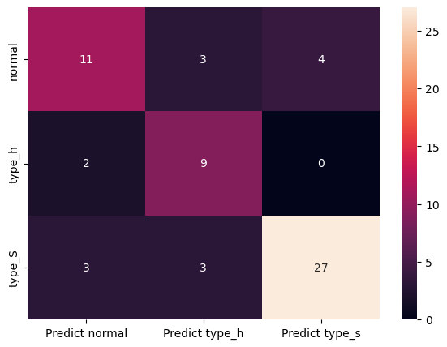

```python
from sklearn import metrics

print("Confusion Matrix")
cm=metrics.confusion_matrix(y_test, predicted_labels, labels=["normal", "type_h", "type_s"])
df_cm = pd.DataFrame(cm, index = [i for i in ["normal","type_h", "type_S"]],
                  columns = [i for i in ["Predict normal","Predict type_h", "Predict type_s"]])
plt.figure(figsize = (7,5))
sns.heatmap(df_cm, annot=True)
```

For normal class the values of the metrics from the confusion matrix are :  
True positive = 11  
True negative = 9+3+27 = 39  
False positive = 3+2 = 5  
False negative = 4+3= 7

for type-h class the values of the metrics from the confusion matrix are:  
True positive = 9  
True negative = 11+4+3+27 = 45  
false positive = 3+3 = 6  
False negative = 2+0 = 2

for type-s class the values of the metrics from the confusion matrix are :  
True positive = 27  
True negative = 11+3+2+9 = 25  
False positive = 4+0 = 4  
False negative = 3+3 = 6

## 5.A

```python
scores =[]
for k in range(1,100):
    NNH = KNeighborsClassifier(n_neighbors = k, weights = 'distance' )
    NNH.fit(X_train, y_train)
    scores.append(NNH.score(X_test, y_test))
```

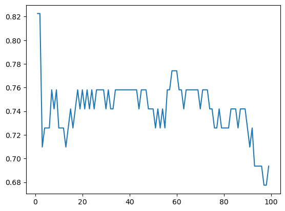

```python
plt.plot(range(1,100),scores)
```

```python
NNH = KNeighborsClassifier(n_neighbors = 1, weights = 'distance' )
NNH.fit(X_train, y_train)
predicted_labels = NNH.predict(X_test)
NNH.score(X_test, y_test)
```

```
0.8225806451612904
```

## 5.B

```python
print("An improvement of ",0.8225806451612904 -  0.7580645161290323," is seen in the model")
```

```
An improvement of  0.06451612903225812  is seen in the model
```

## 5.C

The biggest contributor to the improvement in the model's performance was the amount of nearest neighbors used to calculate the distance for the algorithm i.e  
n-neighbors parameter

# Part B

## 1.A

```python
data1 = pd.read_csv("Part2+-+Data1.csv")
data2 = pd.read_csv("Part2+-Data2.csv")
```

## 1.B

```python
print("data1 shape : ", data1.shape)
print("data2.shape : ", data2.shape, "\ncolumns in data1 : " , data1.columns, "\ncolumns in data2 : ", data2.columns)
data1.dtypes
```

```
data1 shape :  (5000, 8)
data2.shape :  (5000, 7)
columns in data1 :  Index(['ID', 'Age', 'CustomerSince', 'HighestSpend', 'ZipCode', 'HiddenScore',
       'MonthlyAverageSpend', 'Level'],
      dtype='object')
columns in data2 :  Index(['ID', 'Mortgage', 'Security', 'FixedDepositAccount', 'InternetBanking',
       'CreditCard', 'LoanOnCard'],
      dtype='object')
```

```
ID                       int64
Age                      int64
CustomerSince            int64
HighestSpend             int64
ZipCode                  int64
HiddenScore              int64
MonthlyAverageSpend    float64
Level                    int64
dtype: object
```

```python
data2.dtypes
```

```
ID                       int64
Mortgage                 int64
Security                 int64
FixedDepositAccount      int64
InternetBanking          int64
CreditCard               int64
LoanOnCard             float64
dtype: object
```

## 1.C

```python
data = pd.merge(data1, data2, how="inner", on="ID")
```

## 1.D

```python
data[["CreditCard", "InternetBanking", "FixedDepositAccount", "Security", "Level", "HiddenScore"]] = data[["CreditCard", "InternetBanking", "FixedDepositAccount", "Security", "Level", "HiddenScore"]].astype("object")
data.dtypes
```

```
ID                       int64
Age                      int64
CustomerSince            int64
HighestSpend             int64
ZipCode                  int64
HiddenScore             object
MonthlyAverageSpend    float64
Level                   object
Mortgage                 int64
Security                object
FixedDepositAccount     object
InternetBanking         object
CreditCard              object
LoanOnCard             float64
dtype: object
```

## 2.B

```python
percent_missing = data.isnull().sum() * 100 / len(data)
missing_value_df = pd.DataFrame({'column_name': data.columns,
                                 'percent_missing': percent_missing})
display(missing_value_df)
```

|  | column_name | percent_missing |
| --- | --- | --- |
| ID | ID | 0.0 |
| Age | Age | 0.0 |
| CustomerSince | CustomerSince | 0.0 |
| HighestSpend | HighestSpend | 0.0 |
| ZipCode | ZipCode | 0.0 |
| HiddenScore | HiddenScore | 0.0 |
| MonthlyAverageSpend | MonthlyAverageSpend | 0.0 |
| Level | Level | 0.0 |
| Mortgage | Mortgage | 0.0 |
| Security | Security | 0.0 |
| FixedDepositAccount | FixedDepositAccount | 0.0 |
| InternetBanking | InternetBanking | 0.0 |
| CreditCard | CreditCard | 0.0 |
| LoanOnCard | LoanOnCard | 0.4 |

```python
data.dropna(inplace=True)
```

## 2.C

```python
data.sample(5)
```

|  | ID | Age | CustomerSince | HighestSpend | ZipCode | HiddenScore | MonthlyAverageSpend | Level | Mortgage | Security | FixedDepositAccount | InternetBanking | CreditCard | LoanOnCard |
| --- | --- | --- | --- | --- | --- | --- | --- | --- | --- | --- | --- | --- | --- | --- |
| 2390 | 2391 | 33 | 9 | 41 | 95814 | 3 | 2.0 | 1 | 108 | 0 | 0 | 1 | 0 | 0.0 |
| 2623 | 2624 | 42 | 17 | 111 | 94304 | 3 | 3.0 | 1 | 0 | 1 | 1 | 0 | 1 | 1.0 |
| 3982 | 3983 | 24 | 0 | 119 | 94566 | 1 | 1.5 | 1 | 0 | 0 | 0 | 1 | 0 | 0.0 |
| 2473 | 2474 | 57 | 32 | 39 | 92182 | 4 | 0.9 | 1 | 147 | 0 | 0 | 0 | 0 | 0.0 |
| 2894 | 2895 | 49 | 25 | 19 | 94545 | 1 | 0.9 | 3 | 0 | 0 | 0 | 0 | 0 | 0.0 |

## 3.A

```python
data.drop( ["ID" , "ZipCode"], axis = 1, inplace=True)
```

```python
X = data.drop(labels="LoanOnCard" , axis=1)
y = data["LoanOnCard"]
```

## 3.B

```python
X_train, X_test, y_train, y_test = train_test_split(X, y, test_size=0.25, random_state=1)
```

## 3.C

```python
from sklearn import metrics

from sklearn.linear_model import LogisticRegression


model = LogisticRegression(solver="liblinear")
model.fit(X_train, y_train)

y_predict = model.predict(X_test)
```

```python
model_score = model.score(X_test, y_test)
print(model_score)
```

```
0.9477911646586346
```

## 3.D

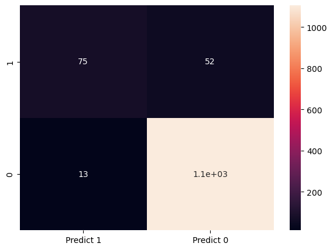

```python
cm=metrics.confusion_matrix(y_test, y_predict, labels=[1, 0])

df_cm = pd.DataFrame(cm, index = [i for i in ["1","0"]],
                  columns = [i for i in ["Predict 1","Predict 0"]])
plt.figure(figsize = (7,5))
sns.heatmap(df_cm, annot=True)
```

True Positives (TP): we correctly predicted that they have loan on their credit card 75

True Negatives (TN): we correctly predicted that they don't have loans on their credit card 1105

False Positives (FP): we incorrectly predicted that they do have loans on their card - 13 Falsely predict positive (Type I error)

False Negatives (FN): we incorrectly predicted that they don't have loans on their card -52 Falsely predict negative (Type II error)

## 4.A

```python
NNH = KNeighborsClassifier(n_neighbors= 5 , weights = 'distance' )
NNH.fit(X_train, y_train)
```

```
KNeighborsClassifier(weights='distance')
```

```python
predicted_labels = NNH.predict(X_test)
NNH.score(X_test, y_test)
```

```
0.9004016064257028
```

```python
clf = svm.SVC(gamma=0.025, C=3)
```

```python
clf.fit(X_train , y_train)
```

```
SVC(C=3, gamma=0.025)
```

```python
y_pred = clf.predict(X_test)
```

```python
print(accuracy_score(y_test, y_pred)*100)
```

```
91.64658634538154
```

## 4.B

```python
scores_1 =[]
for k in range(1,100):
    NNH = KNeighborsClassifier(n_neighbors = k, weights = 'distance' )
    NNH.fit(X_train, y_train)
    scores_1.append(NNH.score(X_test, y_test))
```

```python
n_n = scores_1.index(max(scores_1))
print(n_n)
```

```
3
```

```python
NNH_2 = KNeighborsClassifier(n_neighbors= 3 , weights = 'distance' )
NNH_2.fit(X_train, y_train)
```

```
KNeighborsClassifier(n_neighbors=3, weights='distance')
```

```python
predicted_labels = NNH.predict(X_test)
NNH_2.score(X_test, y_test)
```

```
0.9020080321285141
```

## 4.C

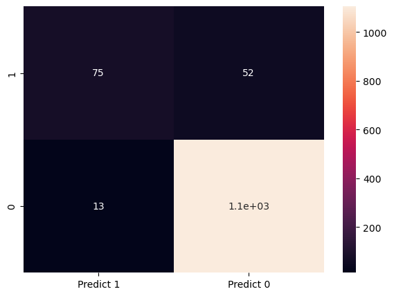

```python
cm=metrics.confusion_matrix(y_test, y_predict, labels=[1, 0])

df_cm = pd.DataFrame(cm, index = [i for i in ["1","0"]],
                  columns = [i for i in ["Predict 1","Predict 0"]])
plt.figure(figsize = (7,5))
sns.heatmap(df_cm, annot=True)
```

## 4.D

```python
print("An improvement of ",0.9020080321285141 -  0.9004016064257028," is seen in the model")
```

```
An improvement of  0.0016064257028113316  is seen in the model
```